# EDA Case Study - Day 01

### Problem Statement

“what sorts of people were more likely to survive?”

```python
import numpy as np
import pandas as pd

import matplotlib.pyplot as plt
import seaborn as sns
```

```python
train = pd.read_csv("~/Downloads/Train.csv")
test = pd.read_csv("~/Downloads/Test.csv")
```

```python
train.head(1)
```

|  | PassengerId | Survived | Pclass | Name | Sex | Age | SibSp | Parch | Ticket | Fare | Cabin | Embarked |
| --- | --- | --- | --- | --- | --- | --- | --- | --- | --- | --- | --- | --- |
| 0 | 1 | 0 | 3 | Braund, Mr. Owen Harris | male | 22.0 | 1 | 0 | A/5 21171 | 7.25 | NaN | S |

### Steps to the EDA

1. Univariate Analysis: One Variable Analysis
2. Num Variables - Distplot, Histogram, Boxplots...
3. Cat variables: Frequency Plot using value_counts(), Countplot..
4. Bivariate Analysis
5. Num Variable vs Target variable: If the tgt variable is numerical, then we make **scatterplot**
6. Cat Variable vs Target Variable (Num) - Boxplot, barplots, Violinplots...
7. Cat variable vs Cat Variable - frequency table using pd.crosstab, Countplot...
8. Missing Values
9. Outlier Identification, Analysis and Removal...
10. **Feature Engineering**
11. Statistical Analysis ( Validation of Hypothesis Using Statistical Tests)
12. Data Preprocessing - Standardization & Encoding...

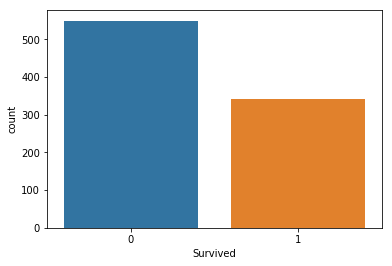

```python
# Survived

sns.countplot(train.Survived)
```

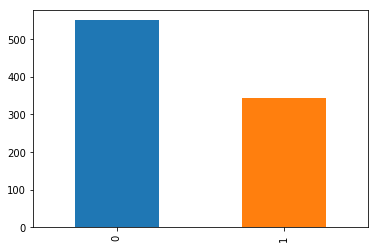

```python
train.Survived.value_counts().plot(kind = "bar")
```

Inference: On the board of titanic, the count of passengers who survived is less than the ones who died

```python
train.columns
```

```
Index(['PassengerId', 'Survived', 'Pclass', 'Name', 'Sex', 'Age', 'SibSp',
       'Parch', 'Ticket', 'Fare', 'Cabin', 'Embarked'],
      dtype='object')
```

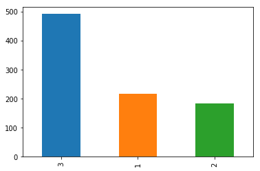

```python
# Pclass

train.Pclass.value_counts().plot(kind = "bar")

# Inf: Majority of Passengers belong to Class 3, followed by Class1 & 2
```

```python
train.Name.value_counts()
```

[output not shown]

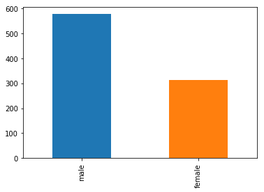

```python
train.Sex.value_counts().plot(kind = "bar")

# Inf: More Males on the Board of Titanic incomparison to Females
```

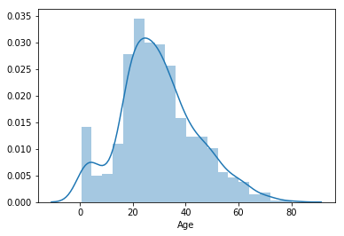

```python
# Age

sns.distplot(train.Age.dropna())

# Inf: By Looking at the Plot, we see that we have infants and senior citizens too.
```

```python
# Desc Statistics

train.Age.describe()
```

```
count    714.000000
mean      29.699118
std       14.526497
min        0.420000
25%       20.125000
50%       28.000000
75%       38.000000
max       80.000000
Name: Age, dtype: float64
```

```python
train.columns
```

```
Index(['PassengerId', 'Survived', 'Pclass', 'Name', 'Sex', 'Age', 'SibSp',
       'Parch', 'Ticket', 'Fare', 'Cabin', 'Embarked'],
      dtype='object')
```

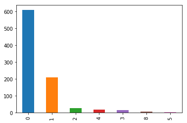

```python
train.SibSp.value_counts().plot(kind = "bar")
```

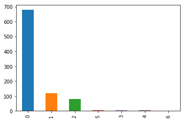

```python
train.Parch.value_counts().plot(kind = "bar")
```

```python
train.info()
```

```
<class 'pandas.core.frame.DataFrame'>
RangeIndex: 891 entries, 0 to 890
Data columns (total 12 columns):
PassengerId    891 non-null int64
Survived       891 non-null int64
Pclass         891 non-null int64
Name           891 non-null object
Sex            891 non-null object
Age            714 non-null float64
SibSp          891 non-null int64
Parch          891 non-null int64
Ticket         891 non-null object
Fare           891 non-null float64
Cabin          204 non-null object
Embarked       889 non-null object
dtypes: float64(2), int64(5), object(5)
memory usage: 83.6+ KB
```

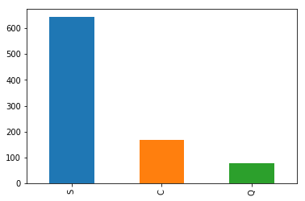

```python
train.Embarked.value_counts().plot(kind = "bar")
```